# **Panorama da inflação**

Os principais índices de inflação do Brasil, apontam em agosto de 2016 um avanço da inflação de em média **0.30%**. Com esse resultado, no ano a inflação acumula uma variação média positiva de **5.52%**, e em 12 meses uma variação média acumulada de **10.03%**.

[output not shown]

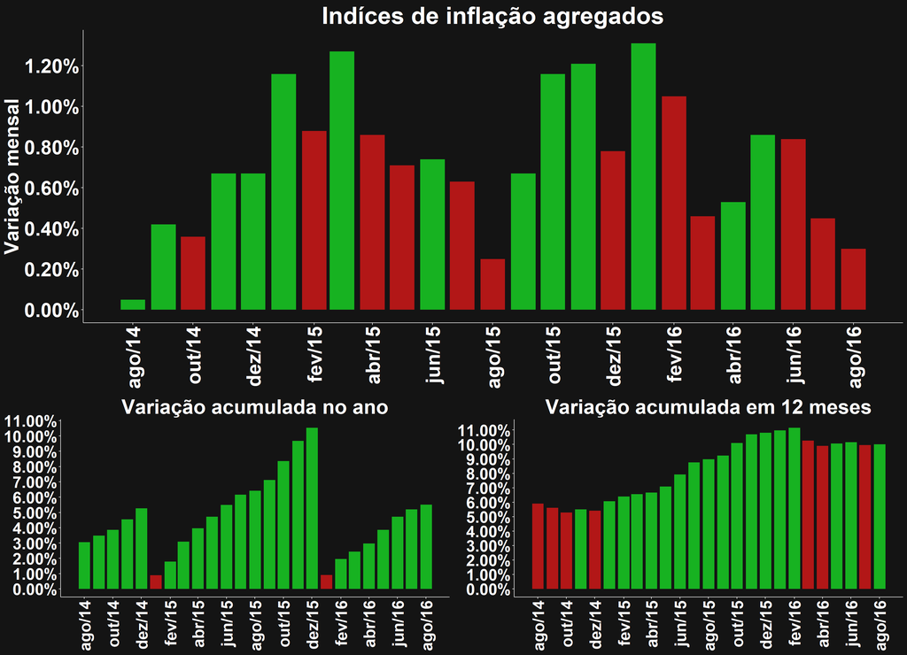

Índices selecionados para a média: IPCA, INPC e IGP-M.

# IPCA

O Indíce de Preços ao Consumidor Amplo (IPCA) variou 0.44% em agosto, valor superior ao mesmo período do ano anterior quando apresentou uma taxa de 0.22%. Com esse resultado o indíce acumula no ano uma variação positiva de 5.42%, e em 12 meses uma variação positiva de 8.97%.

|  | 08/2015 | 07/2016 | 08/2016 |
| --- | --- | --- | --- |
| Variação mensal | 0.22% | 0.52% | 0.44% |
| Variação acumulada no ano | 7.06% | 4.96% | 5.42% |
| Variação acumulada em 12 meses | 9.53% | 8.74% | 8.97% |

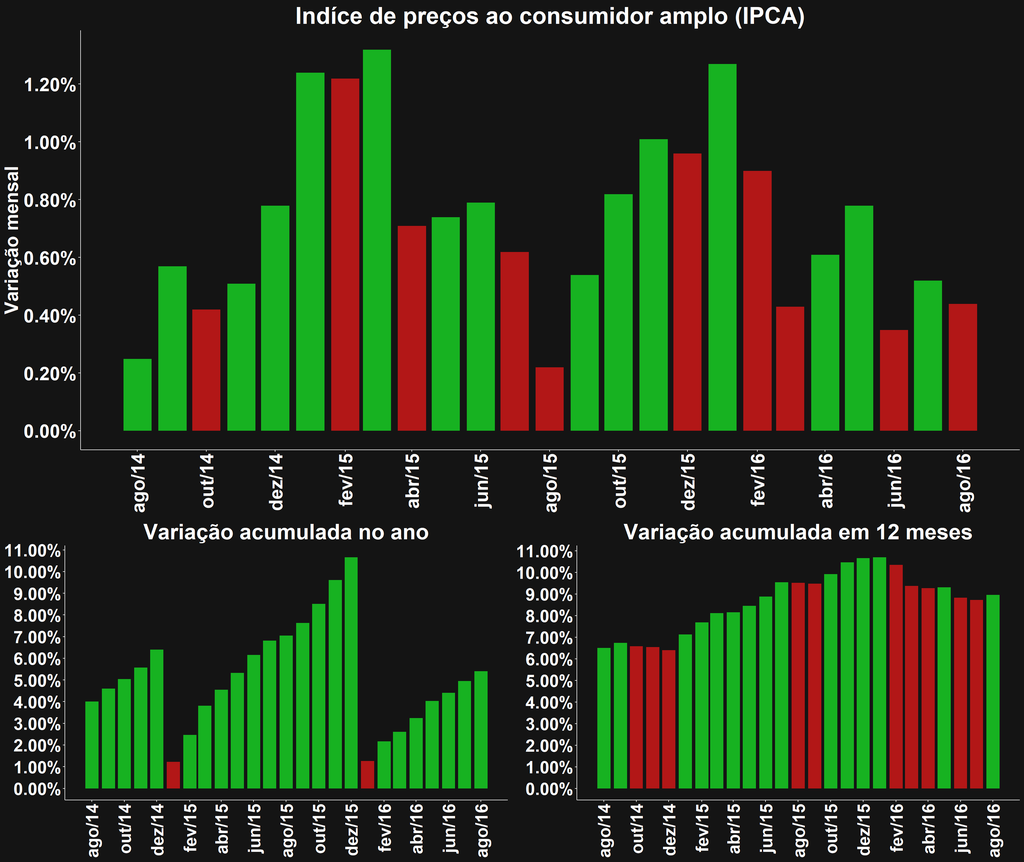

|  | Variação mensal | Variação acumulada no ano | Peso mensal |
| --- | --- | --- | --- |
| Alimentação e bebidas | 0.3% | 9.11% | 26.14% |
| Habitação | 0.3% | 2.07% | 15.27% |
| Artigos de residência | 0.36% | 4.28% | 4.23% |
| Vestuário | 0.15% | 2.1% | 5.94% |
| Transportes | 0.27% | 2.14% | 17.9% |
| Saúde e cuidados pessoais | 0.8% | 9.05% | 11.49% |
| Despesas pessoais | 0.96% | 6.31% | 10.67% |
| Educação | 0.99% | 8.51% | 4.64% |
| Comunicação | -0.02% | 0.73% | 3.72% |

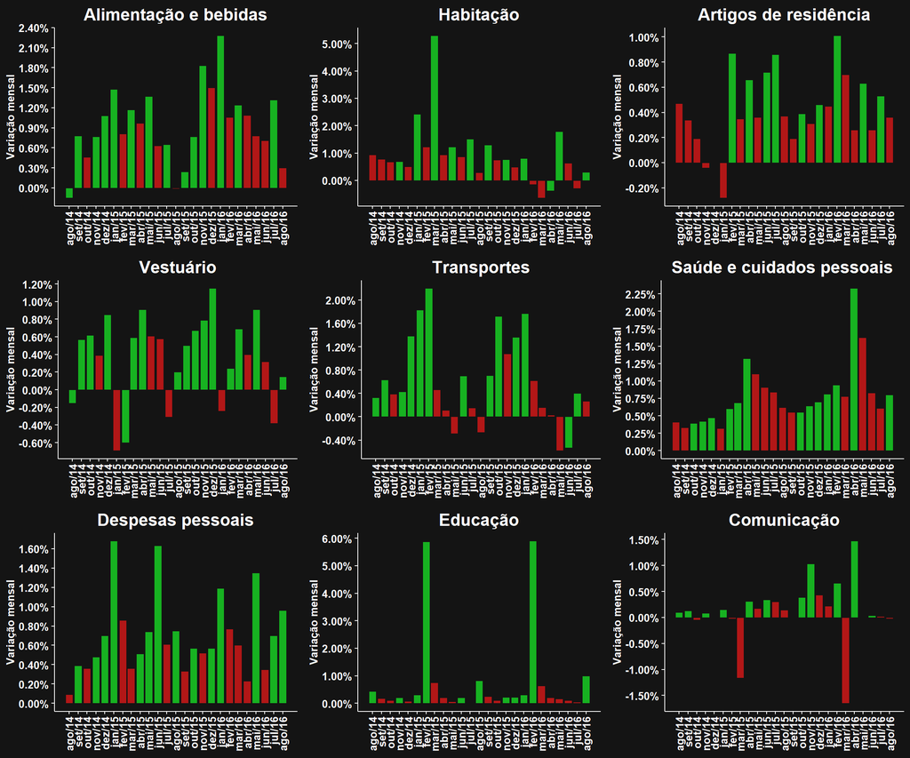

A nível de sub-itens os que mais influenciaram positivamente no resultado em relação ao seu peso foram Hotel (11.58%%) e Plano de saúde (1.07%%), e negativamente Feijão - carioca (rajado) (-5.6%%) e Batata-inglesa (-8%%).

|  | Variação mensal | Variação acumulada no ano | Peso mensal |
| --- | --- | --- | --- |
| Leite longa vida | 2.52% | 52.74% | 1.29% |
| Hotel | 11.58% | 8.47% | 0.35% |
| Plano de saúde | 1.07% | 8.83% | 3.4% |
| Empregado doméstico | 0.87% | 6.51% | 4.03% |

|  | Variação mensal | Variação acumulada no ano | Peso mensal |
| --- | --- | --- | --- |
| Cebola | -18.46% | -36.95% | 0.13% |
| Passagem aérea | -3.85% | -28.26% | 0.37% |
| Feijão - carioca (rajado) | -5.6% | 136.57% | 0.51% |
| Batata-inglesa | -8% | 13.39% | 0.33% |

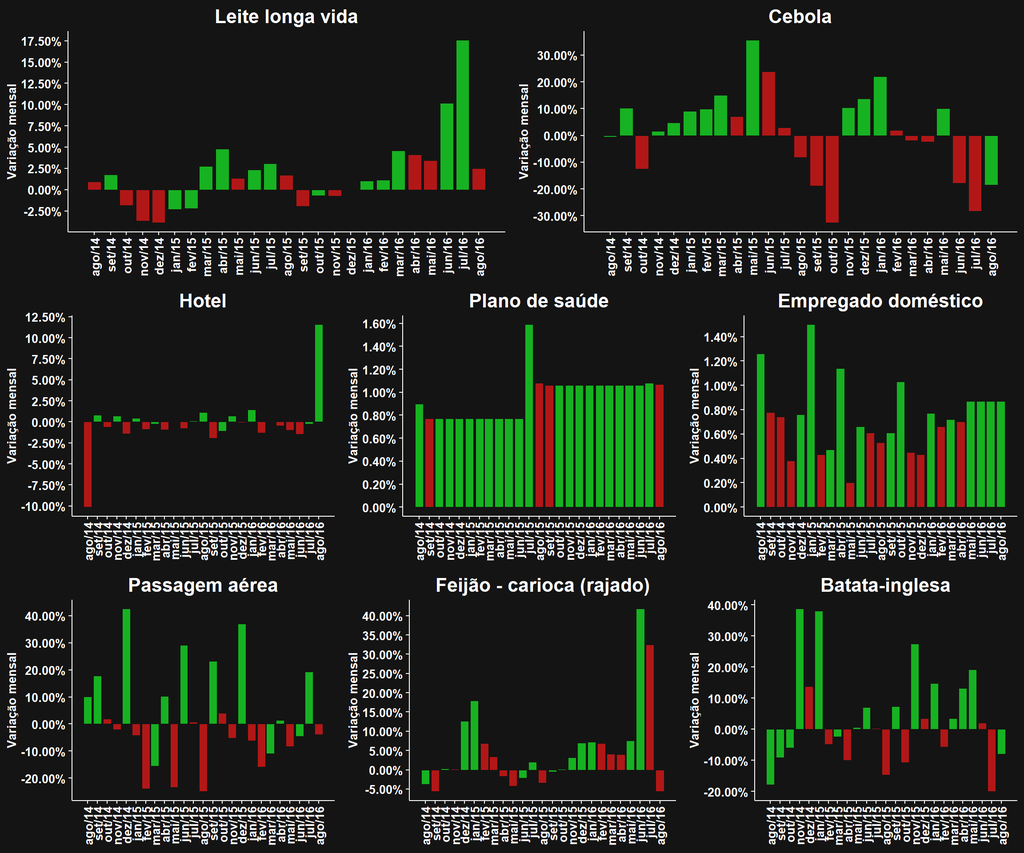

# INPC

O Indíce Nacional de Preços ao Consumidor (INPC) variou 0.31% em agosto, valor superior ao mesmo período do ano anterior quando apresentou uma taxa de 0.25%. Com esse resultado o indíce acumula no ano uma variação positiva de 6.09%, e em 12 meses uma variação positiva de 9.62%.

|  | 08/2015 | 07/2016 | 08/2016 |
| --- | --- | --- | --- |
| Variação mensal | 0.25% | 0.64% | 0.31% |
| Variação acumulada no ano | 7.69% | 5.76% | 6.09% |
| Variação acumulada em 12 meses | 9.88% | 9.56% | 9.62% |

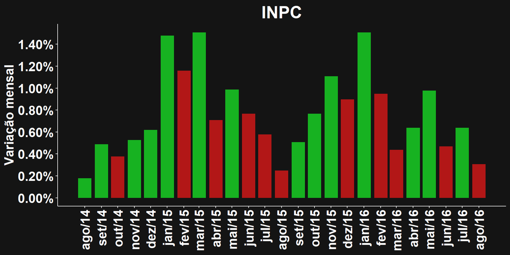

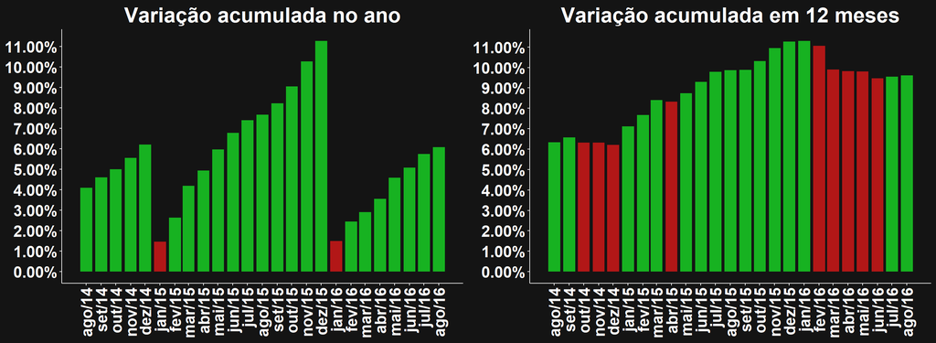

# IGP-M

|  | 08/2015 | 07/2016 | 08/2016 |
| --- | --- | --- | --- |
| Variação mensal | 0.28% | 0.18% | 0.15% |
| Variação acumulada no ano | 4.54% | 4.9% | 5.05% |
| Variação acumulada em 12 meses | 7.55% | 11.63% | 11.49% |

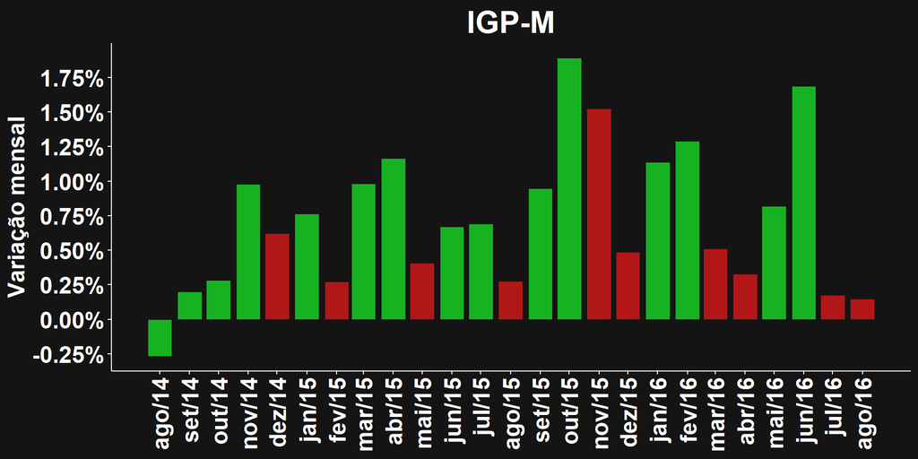

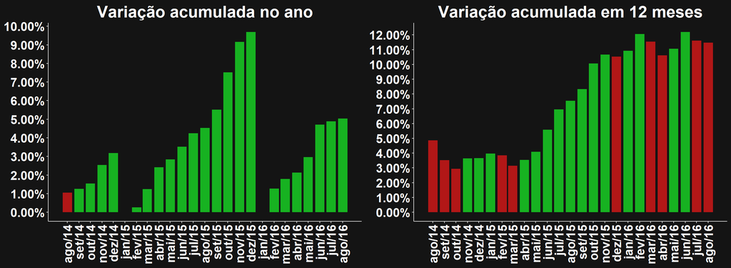

# IGP-DI

O Indíce Geral de Preços - Disponibilidade Interna (IGP-DI) variou 0.43% em agosto, valor superior ao mesmo período do ano anterior quando apresentou uma taxa de 0.4%. Com esse resultado o indíce acumula no ano uma variação positiva de 4.47%, e em 12 meses uma variação positiva de 11.27%.

|  | 08/2015 | 07/2016 | 08/2016 |
| --- | --- | --- | --- |
| Variação mensal | 0.4% | -0.39% | 0.43% |
| Variação acumulada no ano | 4.83% | 4.02% | 4.47% |
| Variação acumulada em 12 meses | 7.8% | 11.23% | 11.27% |

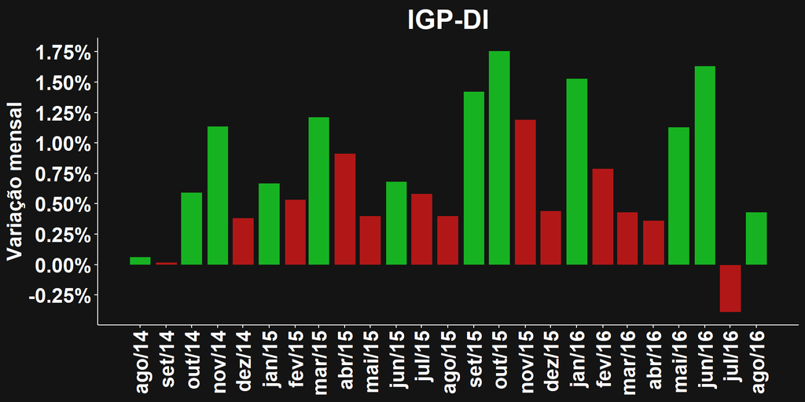

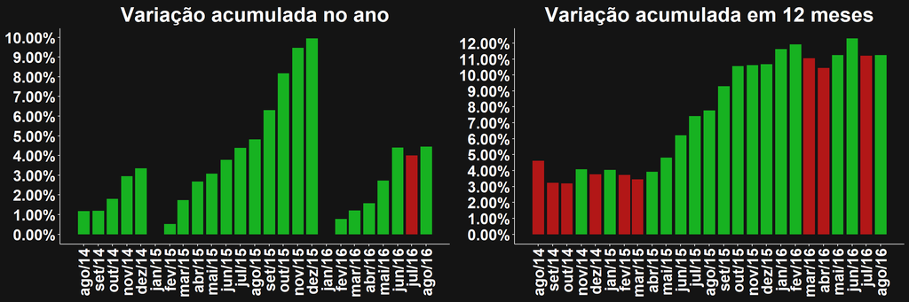

[output not shown]

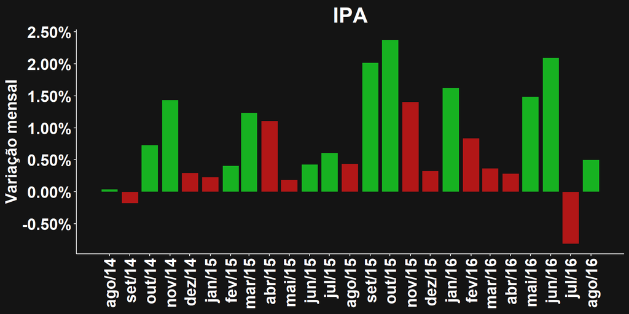

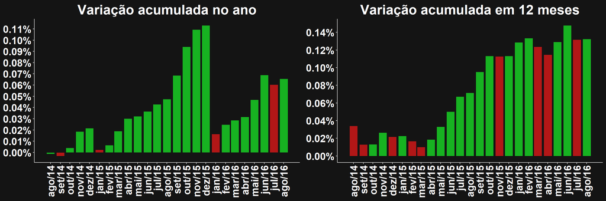

O Indíce de Preços ao Consumidor (IPC), integrante do IGP-DI com peso de 30%, apresentou variação de 0.32% em agosto, valor superior ao mesmo período do ano anterior quando apresentou uma taxa de 0.22%. Com esse resultado o indíce acumula no ano uma variação positiva de 3.38%, e em 12 meses uma variação positiva de 8.48%.

|  | 08/2015 | 07/2016 | 08/2016 |
| --- | --- | --- | --- |
| Variação mensal | 0.22% | 0.37% | 0.32% |
| Variação acumulada no ano | 5.39% | 3.05% | 3.38% |
| Variação acumulada em 12 meses | 9.73% | 8.37% | 8.48% |

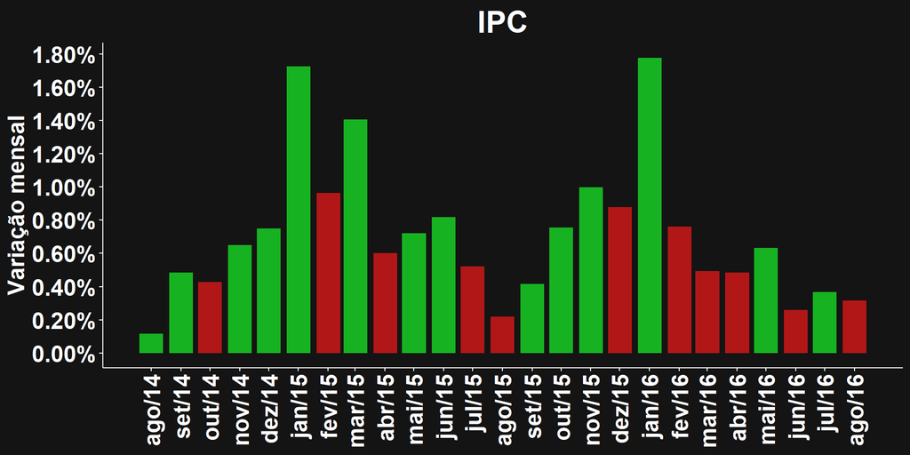

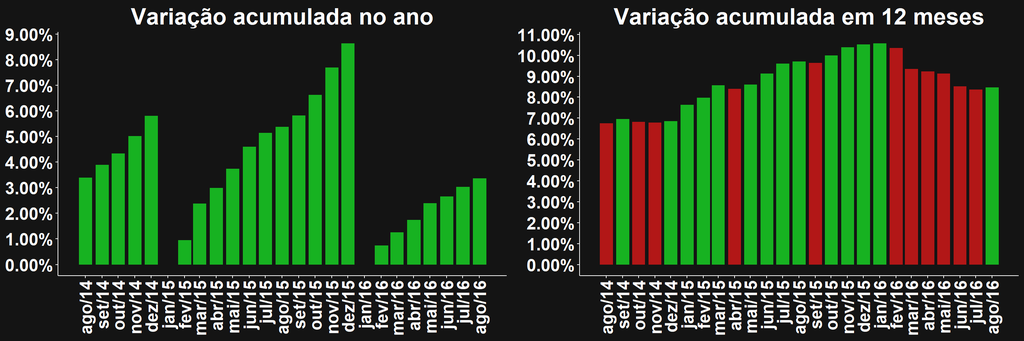

|  | 08/2015 | 07/2016 | 08/2016 |
| --- | --- | --- | --- |
| Variação mensal | 0.59% | 0.49% | 0.29% |
| Variação acumulada no ano | 5.43% | 4.29% | 4.6% |
| Variação acumulada em 12 meses | 7.3% | 6.4% | 6.09% |

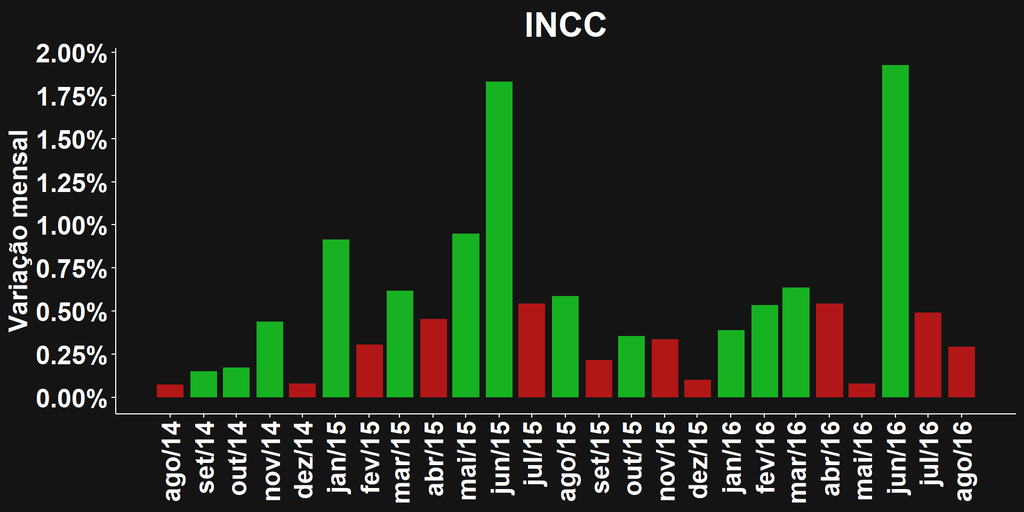

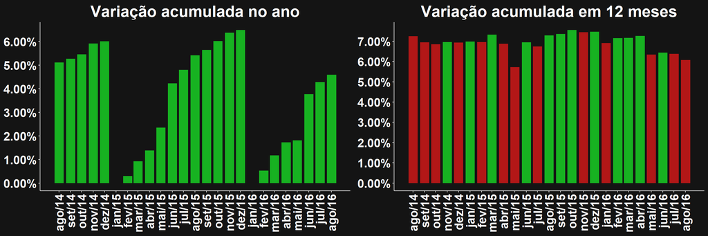

# Estatísticas

As estatísticas descritivas a seguir são feitas com base nos últimos 48 meses, e tem como objetivo possibilitar a avaliação do resultado observado em comparação aos períodos anteriores.

|  | Minimo | 1 Quartil | Mediana | Media | 3 Quartil | Maximo | Desvio Padrão |
| --- | --- | --- | --- | --- | --- | --- | --- |
| IPCA | 0.01% | 0.44% | 0.58% | 0.63% | 0.79% | 1.32% | 0.3% |
| INPC | -0.13% | 0.46% | 0.62% | 0.64% | 0.77% | 1.51% | 0.34% |
| IGP-M | -0.74% | 0.2% | 0.48% | 0.56% | 0.88% | 1.89% | 0.57% |
| IGP-DI | -0.63% | 0.3% | 0.46% | 0.56% | 0.85% | 1.76% | 0.56% |
| IPA | -1.21% | 0.12% | 0.42% | 0.54% | 1.03% | 2.38% | 0.83% |
| IPC | -0.17% | 0.37% | 0.55% | 0.61% | 0.76% | 1.78% | 0.37% |
| INCC | 0.08% | 0.27% | 0.45% | 0.58% | 0.65% | 2.25% | 0.51% |

Levando em consideração o desvio padrão de cada indíce, proporcionalmente os que mais se afastaram da média foram o INPC, o IPC e o IGP-M.

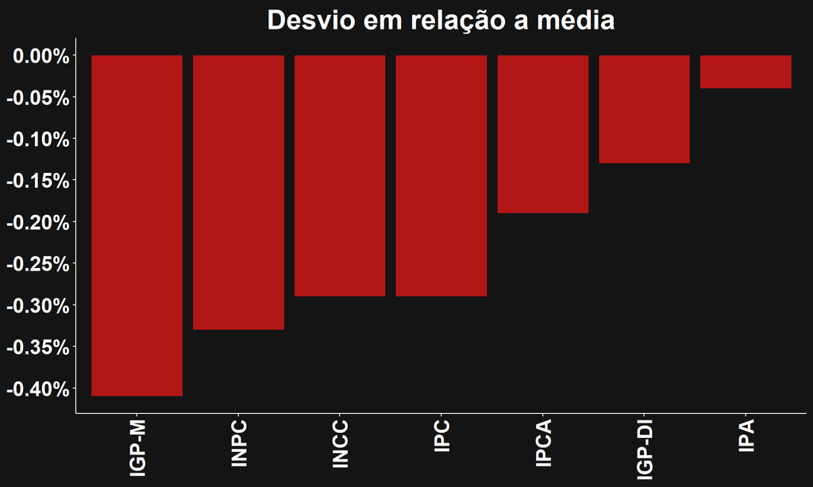

**João Victor Gomes**  
**jvg.santana@gmail.com**  
**[linkedin.com/in/jvictorgomes](https://www.linkedin.com/in/jvictorgomes/)**